# CourseraProj1

AnnoD

24 lipca 2016

## Project 1

This is a Project1 document.  
First, we import dataset **“activity.csv”**

```r
activity <- read.csv("activity.csv")
```

## Cleaning dataset

We need to aggregate data set by date. In this step we creating *wyn* variable, apropriate naming columns and making a histogram. For the clear view we plot dataset after that. As we can see the histogram is adequate to the real data:

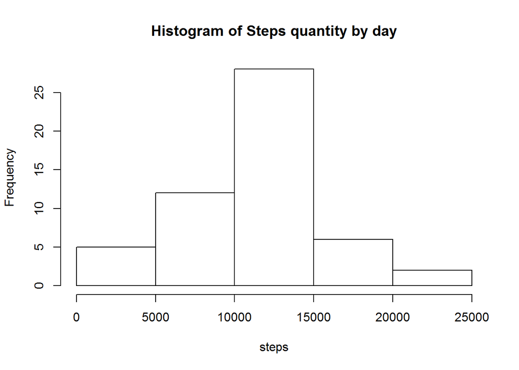

```r
wyn<-aggregate(activity$steps,by=list(activity$date),FUN=sum)
names(wyn) <- c("data","steps")
hist(wyn$step,xlab="steps",main = "Histogram of Steps quantity by day")
```

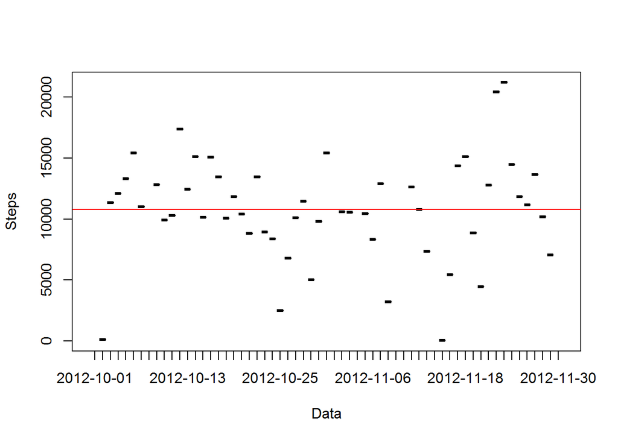

```r
plot(wyn,xlab="Data",ylab="Steps",type="h")
abline(h=median(wyn$steps,na.rm = TRUE),col="blue")
abline(h=mean(wyn$steps,na.rm = TRUE),col="red")
```

Now, we can calculate mean and median for this set. On previous plot are they represented as *red* line for mean and *blue* line for median.

```r
  ext1<-format(mean(wyn$steps,na.rm = TRUE),scientific = FALSE)
  ext2<-median(wyn$steps,na.rm = TRUE)
  ext3 <- sum(wyn$steps,na.rm = TRUE)
```

After that, we know that mean is 10766.19 and median is 10765 with all steps in numer 570608.

======================================================================

```r
  DaysWithNA <- sum(is.na(wyn$steps))
  intervalCount <- 24*12
  AllDaysMeasurment <- sum(wyn$data!="")
```

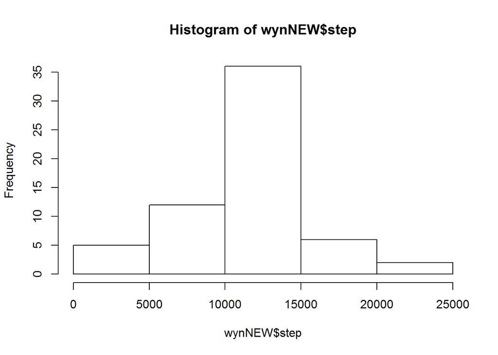

```r
  wynNEW <- wyn
  names(wynNEW) <- c("data", "steps")
  wynNEW$steps[is.na(wyn$steps)]<-ext2
  hist(wynNEW$step)
```